```r
library(data.table)
library(glmnet)
library(ggplot2)
library(lubridate, quietly=TRUE)
library(zoo, quietly = TRUE)
library(dplyr, quietly = TRUE)
library(GGally, quietly=TRUE)
library(caTools)
library(rpart)
library(rattle)
library(caret)
library(e1071)
library(randomForest)
library(gbm)
library(fastDummies)
```

### Performance Function

```r
perf_dt=function(type,actual,forecast){
    name=type
    n=length(actual)
    error=actual-forecast
    mean=mean(actual)
    sd=sd(actual)
    FBias=sum(error)/sum(actual)
    MPE=sum(error/actual)/n
    MAPE=sum(abs(error/actual))/n
    RMSE=sqrt(sum(error^2))/n
    MAD=sum(abs(error))/n
    WMAPE=MAD/mean
    l=data.frame(name,n,mean,sd,FBias,MAPE,RMSE,MAD,WMAPE)
    return(l)
}
```

# Student Performance Dataset

Attribute Information:

instr: Instructor's identifier; values taken from {1,2,3}

class: Course code (descriptor); values taken from {1-13}

repeat: Number of times the student is taking this course; values taken from {0,1,2,3,...}

attendance: Code of the level of attendance; values from {0, 1, 2, 3, 4}

difficulty: Level of difficulty of the course as perceived by the student; values taken from {1,2,3,4,5}

Q1: The semester course content, teaching method and evaluation system were provided at the start.

Q2: The course aims and objectives were clearly stated at the beginning of the period.

Q3: The course was worth the amount of credit assigned to it.

Q4: The course was taught according to the syllabus announced on the first day of class.

Q5: The class discussions, homework assignments, applications and studies were satisfactory.

Q6: The textbook and other courses resources were sufficient and up to date.

Q7: The course allowed field work, applications, laboratory, discussion and other studies.

Q8: The quizzes, assignments, projects and exams contributed to helping the learning.

Q9: I greatly enjoyed the class and was eager to actively participate during the lectures.

Q10: My initial expectations about the course were met at the end of the period or year.

Q11: The course was relevant and beneficial to my professional development.

Q12: The course helped me look at life and the world with a new perspective.

Q13: The Instructor's knowledge was relevant and up to date.

Q14: The Instructor came prepared for classes.

Q15: The Instructor taught in accordance with the announced lesson plan.

Q16: The Instructor was committed to the course and was understandable.

Q17: The Instructor arrived on time for classes.

Q18: The Instructor has a smooth and easy to follow delivery/speech.

Q19: The Instructor made effective use of class hours.

Q20: The Instructor explained the course and was eager to be helpful to students.

Q21: The Instructor demonstrated a positive approach to students.

Q22: The Instructor was open and respectful of the views of students about the course.

Q23: The Instructor encouraged participation in the course.

Q24: The Instructor gave relevant homework assignments/projects, and helped/guided students.

Q25: The Instructor responded to questions about the course inside and outside of the course.

Q26: The Instructor's evaluation system (midterm and final questions, projects, assignments, etc.) effectively measured the course objectives.

Q27: The Instructor provided solutions to exams and discussed them with students.

Q28: The Instructor treated all students in a right and objective manner.

Q1-Q28 are all Likert-type, meaning that the values are taken from {1,2,3,4,5}

### Loading Dataset

```r
std_eva=read.csv("turkiye-student-evaluation_R_Specific.csv")
std_eva=as.data.table(std_eva)
```

```r
for (i in colnames(std_eva)){
   std_eva[[i]]=as.factor(std_eva[[i]])
}
```

```r
std_eva[,y:=difficulty]
std_eva[,difficulty:=NULL]
```

```r
str(std_eva)
```

```
Classes 'data.table' and 'data.frame':	5820 obs. of  33 variables:
 $ instr     : Factor w/ 3 levels "1","2","3": 1 1 1 1 1 1 1 1 1 1 ...
 $ class     : Factor w/ 13 levels "1","2","3","4",..: 2 2 2 2 2 2 2 2 2 2 ...
 $ nb.repeat : Factor w/ 3 levels "1","2","3": 1 1 1 1 1 1 1 1 1 1 ...
 $ attendance: Factor w/ 5 levels "0","1","2","3",..: 1 2 3 2 1 4 2 2 2 5 ...
 $ Q1        : Factor w/ 5 levels "1","2","3","4",..: 3 3 5 3 1 4 4 5 4 4 ...
 $ Q2        : Factor w/ 5 levels "1","2","3","4",..: 3 3 5 3 1 4 4 5 4 4 ...
 $ Q3        : Factor w/ 5 levels "1","2","3","4",..: 3 3 5 3 1 4 4 5 4 4 ...
 $ Q4        : Factor w/ 5 levels "1","2","3","4",..: 3 3 5 3 1 4 4 5 4 4 ...
 $ Q5        : Factor w/ 5 levels "1","2","3","4",..: 3 3 5 3 1 4 4 5 4 4 ...
 $ Q6        : Factor w/ 5 levels "1","2","3","4",..: 3 3 5 3 1 4 4 5 4 4 ...
 $ Q7        : Factor w/ 5 levels "1","2","3","4",..: 3 3 5 3 1 4 4 5 4 4 ...
 $ Q8        : Factor w/ 5 levels "1","2","3","4",..: 3 3 5 3 1 4 4 5 4 4 ...
 $ Q9        : Factor w/ 5 levels "1","2","3","4",..: 3 3 5 3 1 4 4 5 4 4 ...
 $ Q10       : Factor w/ 5 levels "1","2","3","4",..: 3 3 5 3 1 4 4 5 4 4 ...
```

[output cut: 20 more lines]

```r
set.seed(35)
spl=sample.split(std_eva$y, SplitRatio = 0.8)
train=subset(std_eva,spl==TRUE)
test=subset(std_eva,spl==FALSE)
```

## Penalized Regression Approaches(PRA)

### L1 Penalty with Mean Square Error measure

In order to tune lambda values, glmnet packages are used to get best lambda values for Penalized Regression.

```r
train_mat=data.matrix(train[complete.cases(train),-c("y"),with=F])

result_vec=as.vector(t(train[complete.cases(train),"y"]))

cvfit=cv.glmnet(train_mat,result_vec,family="multinomial",nfolds = 10, type.measure="mse")

test_mat=data.matrix(test[complete.cases(test),-c("y")])

lasso_model_mse_min <- glmnet(train_mat,result_vec, alpha = 1, lambda = cvfit$lambda.min, standardize = FALSE,family="multinomial")
lasso_model_mse_1se <- glmnet(train_mat,result_vec, alpha = 1, lambda = cvfit$lambda.1se, standardize = FALSE,family="multinomial")
lasso_model_mse_10th <- glmnet(train_mat,result_vec, alpha = 1, lambda = cvfit$lambda[10], standardize = FALSE,family="multinomial")
```

```r
# train_mat=data.matrix(train[complete.cases(train),-c("y"),with=F])

# result_vec=as.vector(t(train[complete.cases(train),"y"]))

# cvfit=cv.glmnet(train_mat,result_vec,family="multinomial",nfolds = 10)

# test_mat=data.matrix(test[complete.cases(test),-c("y")])

# lasso_model <- glmnet(train_mat,result_vec, alpha = 1, lambda = cvfit$lambda.min, standardize = FALSE,family="multinomial")
```

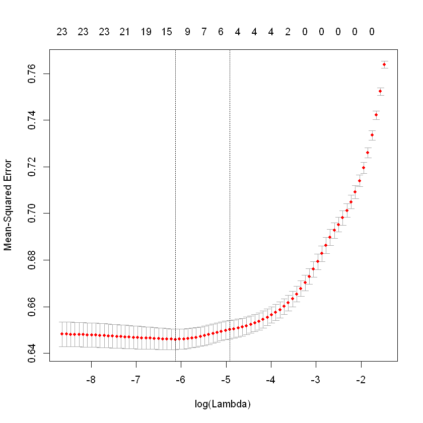

```r
plot(cvfit)
```

### Lambda Values for Mean Square Error Values

```r
cvfit$lambda.min
```

0.00217931358111362

```r
cvfit$lambda.1se
```

0.00730419316746016

```r
cvfit$lambda[10]
```

0.098829222863566

2 possible lambda values are determined by the cv.glmnet(). One of them is used for getting minimum Mean-Squared Error. The other one is determined by looking how many paramater is used in the model. Namely, this lambda value can be beneficial for reducing the possibility of over-fitting model on train dataset. Lastly, one random lambda was selected to compare results for these 3 lambda values.

```r
prediction_pra_mse_min <- predict(lasso_model_mse_min, s = cvfit$lambda.min, newx = test_mat, type="class")
prediction_pra_mse_1se <- predict(lasso_model_mse_1se, s = cvfit$lambda.1se, newx = test_mat, type="class")
prediction_pra_mse_10th <- predict(lasso_model_mse_10th, s = cvfit$lambda[10], newx = test_mat, type="class")
```

## L1 Penalty with Mean Absolute Error measure

```r
train_mat=data.matrix(train[complete.cases(train),-c("y"),with=F])

result_vec=as.vector(t(train[complete.cases(train),"y"]))

cvfit_mae=cv.glmnet(train_mat,result_vec,family="multinomial",nfolds = 10, type.measure="mae")

test_mat=data.matrix(test[complete.cases(test),-c("y")])

lasso_model_mae_min <- glmnet(train_mat,result_vec, alpha = 1, lambda = cvfit_mae$lambda.min, standardize = FALSE,family="multinomial")
lasso_model_mae_1se <- glmnet(train_mat,result_vec, alpha = 1, lambda = cvfit_mae$lambda.1se, standardize = FALSE,family="multinomial")
lasso_model_mae_10th <- glmnet(train_mat,result_vec, alpha = 1, lambda = cvfit_mae$lambda[10], standardize = FALSE,family="multinomial")
```

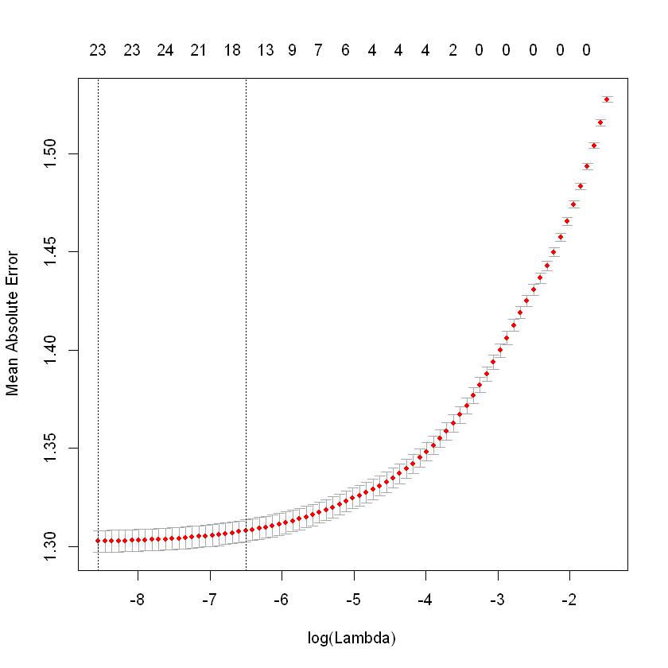

```r
plot(cvfit_mae)
```

```r
cvfit_mae$lambda.min
```

0.000194005783019307

```r
cvfit_mae$lambda.1se
```

0.00150211631735635

```r
cvfit_mae$lambda[10]
```

0.098829222863566

```r
prediction_pra_mae_min <- predict(lasso_model_mae_min, s = cvfit_mae$lambda.min, newx = test_mat, type="class")
prediction_pra_mae_1se <- predict(lasso_model_mae_1se, s = cvfit_mae$lambda.1se, newx = test_mat, type="class")
prediction_pra_mae_10th <- predict(lasso_model_mae_10th, s = cvfit_mae$lambda[10], newx = test_mat, type="class")
```

### Performance Measure for Lasso Regression

```r
perf_dt("Student Data Set for Lasso Function with min lambda and mse objective", as.numeric(test$y), as.numeric(prediction_pra_mse_min))
perf_dt("Student Data Set for Lasso Function with 1se lambda and mse objective", as.numeric(test$y), as.numeric(prediction_pra_mse_1se))
perf_dt("Student Data Set for Lasso Function with 10th lambda and mse objective", as.numeric(test$y), as.numeric(prediction_pra_mse_10th))

perf_dt("Student Data Set for Lasso Function with min lambda and mae objective", as.numeric(test$y), as.numeric(prediction_pra_mae_min))
perf_dt("Student Data Set for Lasso Function with 1se lambda and mae objective", as.numeric(test$y), as.numeric(prediction_pra_mae_1se))
perf_dt("Student Data Set for Lasso Function with 10th lambda and mae objective", as.numeric(test$y), as.numeric(prediction_pra_mae_10th))
```

| name | n | mean | sd | FBias | MAPE | RMSE | MAD | WMAPE |
| --- | --- | --- | --- | --- | --- | --- | --- | --- |
| Student Data Set for Lasso Function with min lambda and mse objective | 1164 | 2.782646 | 1.348866 | 0.1367706 | 0.3633448 | 0.04160241 | 0.9183849 | 0.3300401 |

| name | n | mean | sd | FBias | MAPE | RMSE | MAD | WMAPE |
| --- | --- | --- | --- | --- | --- | --- | --- | --- |
| Student Data Set for Lasso Function with 1se lambda and mse objective | 1164 | 2.782646 | 1.348866 | 0.1769065 | 0.3489404 | 0.04135329 | 0.9218213 | 0.3312751 |

| name | n | mean | sd | FBias | MAPE | RMSE | MAD | WMAPE |
| --- | --- | --- | --- | --- | --- | --- | --- | --- |
| Student Data Set for Lasso Function with 10th lambda and mse objective | 1164 | 2.782646 | 1.348866 | 0.2701451 | 0.3632732 | 0.0456783 | 1.054124 | 0.3788206 |

| name | n | mean | sd | FBias | MAPE | RMSE | MAD | WMAPE |
| --- | --- | --- | --- | --- | --- | --- | --- | --- |
| Student Data Set for Lasso Function with min lambda and mae objective | 1164 | 2.782646 | 1.348866 | 0.1228774 | 0.3716924 | 0.04206991 | 0.9226804 | 0.3315838 |

| name | n | mean | sd | FBias | MAPE | RMSE | MAD | WMAPE |
| --- | --- | --- | --- | --- | --- | --- | --- | --- |
| Student Data Set for Lasso Function with 1se lambda and mae objective | 1164 | 2.782646 | 1.348866 | 0.1305959 | 0.3678694 | 0.04172641 | 0.9218213 | 0.3312751 |

| name | n | mean | sd | FBias | MAPE | RMSE | MAD | WMAPE |
| --- | --- | --- | --- | --- | --- | --- | --- | --- |
| Student Data Set for Lasso Function with 10th lambda and mae objective | 1164 | 2.782646 | 1.348866 | 0.2701451 | 0.3632732 | 0.0456783 | 1.054124 | 0.3788206 |

```r
confusionMatrix(data = as.factor(prediction_pra_mae_min), reference = as.factor(test$y), mode = "prec_recall")
```

```
Confusion Matrix and Statistics

          Reference
Prediction   1   2   3   4   5
         1 249  28  61  49  37
         2   0   1   0   1   0
         3  57  70 255 155  60
         4   9   8  23  29  14
         5   9   3  16  11  19

Overall Statistics

               Accuracy : 0.4751
                 95% CI : (0.4461, 0.5042)
    No Information Rate : 0.305
    P-Value [Acc > NIR] : < 2.2e-16

                  Kappa : 0.2724

 Mcnemar's Test P-Value : < 2.2e-16

Statistics by Class:

                     Class: 1  Class: 2 Class: 3 Class: 4 Class: 5
Precision              0.5873 0.5000000   0.4271  0.34940  0.32759
Recall                 0.7685 0.0090909   0.7183  0.11837  0.14615
F1                     0.6658 0.0178571   0.5357  0.17683  0.20213
Prevalence             0.2784 0.0945017   0.3050  0.21048  0.11168
Detection Rate         0.2139 0.0008591   0.2191  0.02491  0.01632
Detection Prevalence   0.3643 0.0017182   0.5129  0.07131  0.04983
Balanced Accuracy      0.7801 0.5040711   0.6478  0.52980  0.55422
```

### Glmnet with Caret Library

```r
fitControl=trainControl(method = "repeatedcv",
                           number = 10)
```

In order to compare obtained result with resamples function, the same process will be made with caret() library.

```r
lambda_grid <- expand.grid(alpha = 1, lambda = c(cvfit$lambda.min,
                                                 cvfit$lambda.1se,
                                                 cvfit$lambda[10]))
```

```r
lm_model <- train(y ~ ., data = train, method = "glmnet",
                   trControl = fitControl, tuneGrid = lambda_grid)
```

```
glmnet

4656 samples
  32 predictor
   5 classes: '1', '2', '3', '4', '5'

No pre-processing
Resampling: Cross-Validated (10 fold, repeated 1 times)
Summary of sample sizes: 4190, 4190, 4190, 4191, 4190, 4192, ...
Resampling results across tuning parameters:

  lambda       Accuracy   Kappa
  0.002179314  0.5199788  0.3445326
  0.007304193  0.5158988  0.3296490
  0.098829223  0.3047682  0.0000000

Tuning parameter 'alpha' was held constant at a value of 1
Accuracy was used to select the optimal model using the largest value.
The final values used for the model were alpha = 1 and lambda = 0.002179314.
```

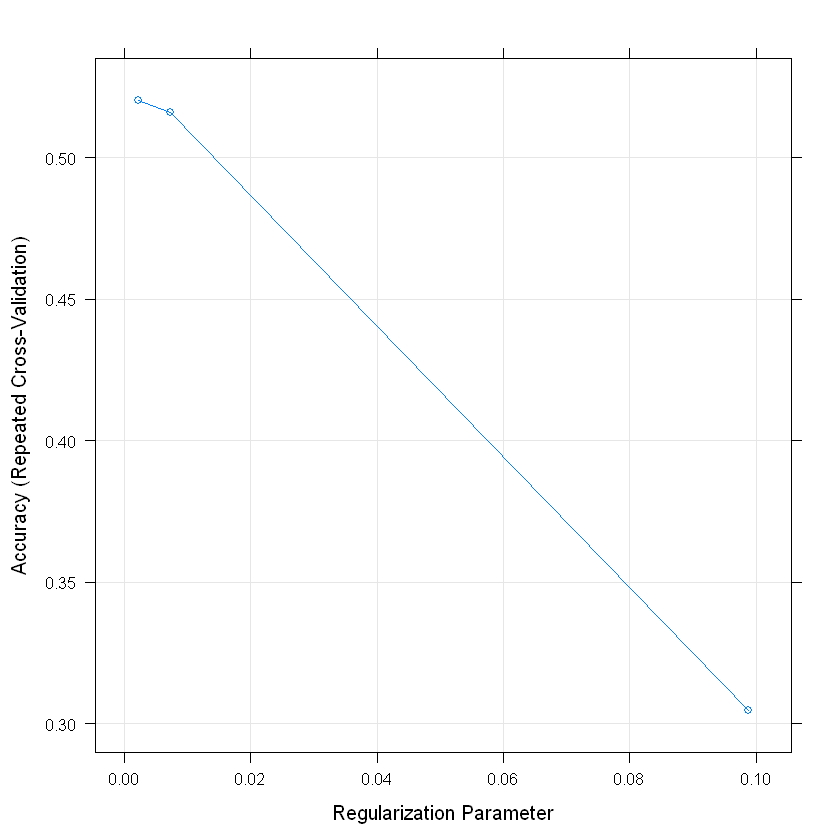

```r
lm_model
plot(lm_model)
```

## Decision Tree(DT)

```r
set.seed(35)
```

```r
train_dt=cbind(train[,"y"],dummy_cols(train[,1:32])[,33:196])
test_dt=cbind(test[,"y"],dummy_cols(test[,1:32])[,33:196])
```

```
CART

4656 samples
 164 predictor
   5 classes: '1', '2', '3', '4', '5'

No pre-processing
Resampling: Cross-Validated (10 fold)
Summary of sample sizes: 4191, 4191, 4191, 4190, 4190, 4189, ...
Resampling results across tuning parameters:

  cp    Accuracy   Kappa
  0.00  0.5098971  0.3282372
  0.02  0.4935544  0.2805483
  0.04  0.4935544  0.2805483
  0.06  0.4935544  0.2805483
  0.08  0.4935544  0.2805483
  0.10  0.4935544  0.2805483
  0.12  0.4935544  0.2805483
  0.14  0.4935544  0.2805483
  0.16  0.4935544  0.2805483
  0.18  0.4935544  0.2805483
  0.20  0.4935544  0.2805483

Accuracy was used to select the optimal model using the largest value.
The final value used for the model was cp = 0.
CART

4656 samples
 164 predictor
   5 classes: '1', '2', '3', '4', '5'

No pre-processing
Resampling: Cross-Validated (10 fold)
Summary of sample sizes: 4190, 4190, 4191, 4190, 4190, 4190, ...
Resampling results across tuning parameters:

  cp    Accuracy   Kappa
  0.00  0.5139601  0.3349571
  0.02  0.4935562  0.2805604
  0.04  0.4935562  0.2805604
  0.06  0.4935562  0.2805604
  0.08  0.4935562  0.2805604
  0.10  0.4935562  0.2805604
  0.12  0.4935562  0.2805604
  0.14  0.4935562  0.2805604
  0.16  0.4935562  0.2805604
  0.18  0.4935562  0.2805604
  0.20  0.4935562  0.2805604

Accuracy was used to select the optimal model using the largest value.
The final value used for the model was cp = 0.
```

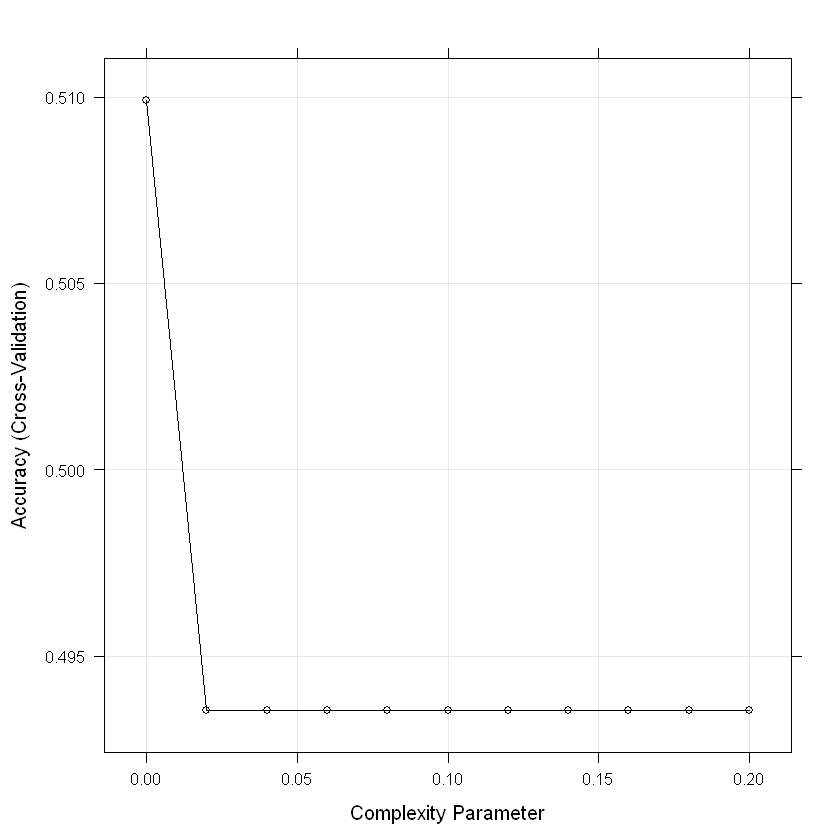

```
CART

4656 samples
 164 predictor
   5 classes: '1', '2', '3', '4', '5'

No pre-processing
Resampling: Cross-Validated (10 fold)
Summary of sample sizes: 4190, 4190, 4190, 4191, 4191, 4191, ...
Resampling results across tuning parameters:

  cp    Accuracy   Kappa
  0.00  0.5133075  0.3330089
  0.02  0.4935608  0.2805711
  0.04  0.4935608  0.2805711
  0.06  0.4935608  0.2805711
  0.08  0.4935608  0.2805711
  0.10  0.4935608  0.2805711
  0.12  0.4935608  0.2805711
  0.14  0.4935608  0.2805711
  0.16  0.4935608  0.2805711
  0.18  0.4935608  0.2805711
  0.20  0.4935608  0.2805711

Accuracy was used to select the optimal model using the largest value.
The final value used for the model was cp = 0.
```

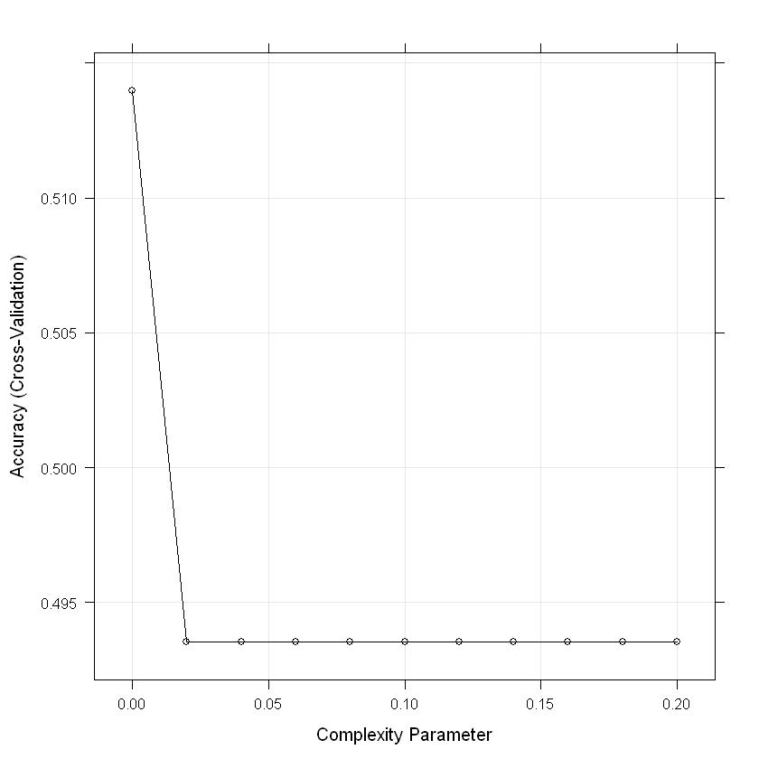

```
CART

4656 samples
 164 predictor
   5 classes: '1', '2', '3', '4', '5'

No pre-processing
Resampling: Cross-Validated (10 fold)
Summary of sample sizes: 4191, 4191, 4191, 4190, 4190, 4189, ...
Resampling results across tuning parameters:

  cp    Accuracy   Kappa
  0.00  0.5150252  0.3351185
  0.02  0.4935604  0.2805660
  0.04  0.4935604  0.2805660
  0.06  0.4935604  0.2805660
  0.08  0.4935604  0.2805660
  0.10  0.4935604  0.2805660
  0.12  0.4935604  0.2805660
  0.14  0.4935604  0.2805660
  0.16  0.4935604  0.2805660
  0.18  0.4935604  0.2805660
  0.20  0.4935604  0.2805660

Accuracy was used to select the optimal model using the largest value.
The final value used for the model was cp = 0.
```

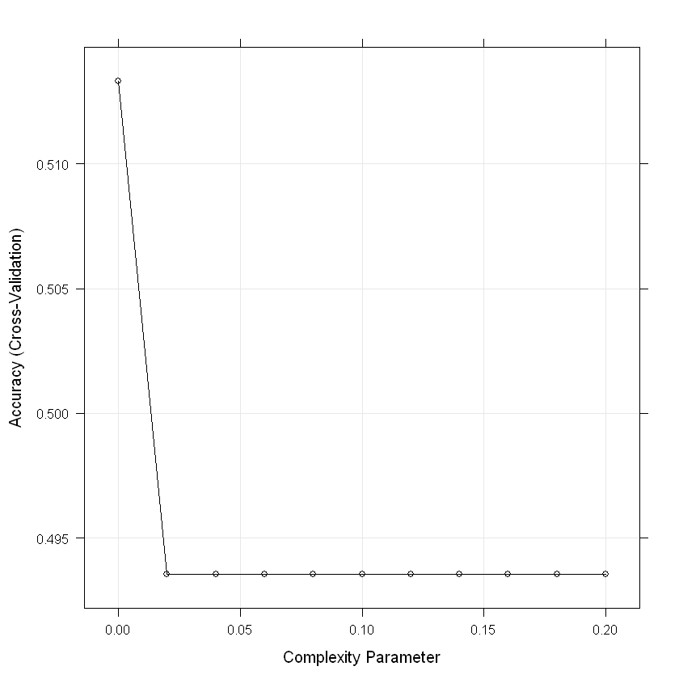

```
CART

4656 samples
 164 predictor
   5 classes: '1', '2', '3', '4', '5'

No pre-processing
Resampling: Cross-Validated (10 fold)
Summary of sample sizes: 4190, 4191, 4190, 4191, 4191, 4190, ...
Resampling results across tuning parameters:

  cp    Accuracy   Kappa
  0.00  0.5098749  0.3286852
  0.02  0.4935558  0.2805471
  0.04  0.4935558  0.2805471
  0.06  0.4935558  0.2805471
  0.08  0.4935558  0.2805471
  0.10  0.4935558  0.2805471
  0.12  0.4935558  0.2805471
  0.14  0.4935558  0.2805471
  0.16  0.4935558  0.2805471
  0.18  0.4935558  0.2805471
  0.20  0.4935558  0.2805471

Accuracy was used to select the optimal model using the largest value.
The final value used for the model was cp = 0.
```

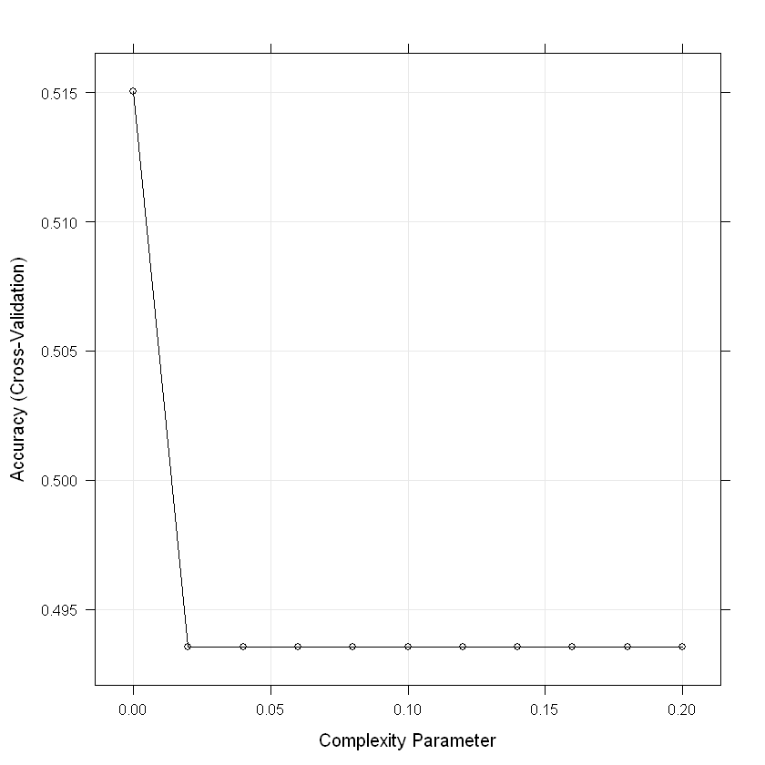

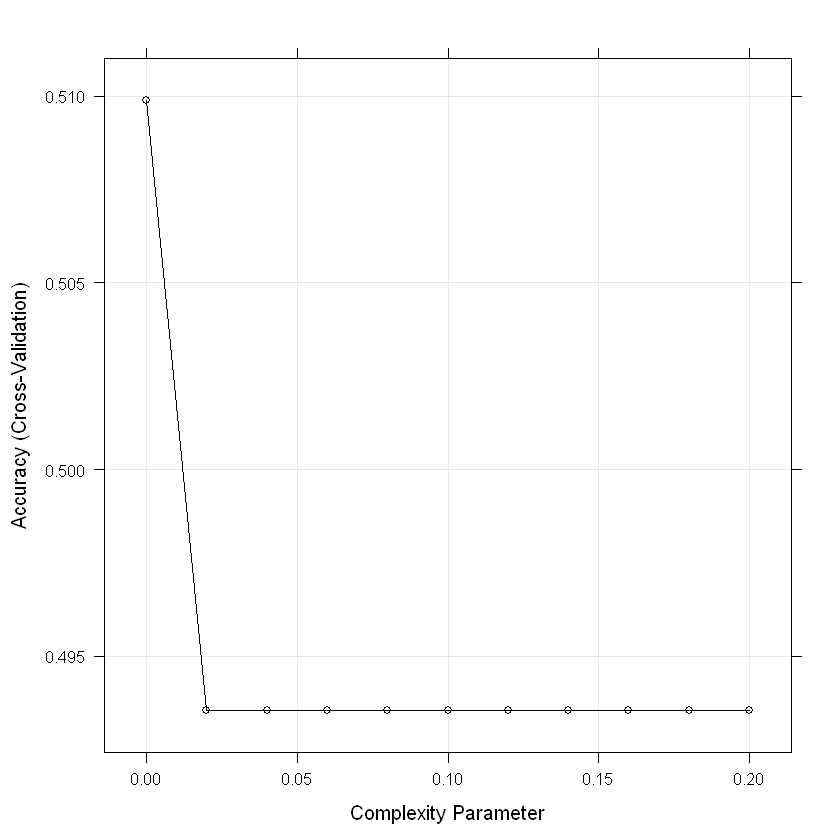

```
CART

4656 samples
 164 predictor
   5 classes: '1', '2', '3', '4', '5'

No pre-processing
Resampling: Cross-Validated (10 fold)
Summary of sample sizes: 4190, 4191, 4191, 4190, 4191, 4190, ...
Resampling results across tuning parameters:

  cp    Accuracy   Kappa
  0.00  0.5070815  0.3240939
  0.02  0.4935535  0.2805507
  0.04  0.4935535  0.2805507
  0.06  0.4935535  0.2805507
  0.08  0.4935535  0.2805507
  0.10  0.4935535  0.2805507
  0.12  0.4935535  0.2805507
  0.14  0.4935535  0.2805507
  0.16  0.4935535  0.2805507
  0.18  0.4935535  0.2805507
  0.20  0.4935535  0.2805507

Accuracy was used to select the optimal model using the largest value.
The final value used for the model was cp = 0.
```

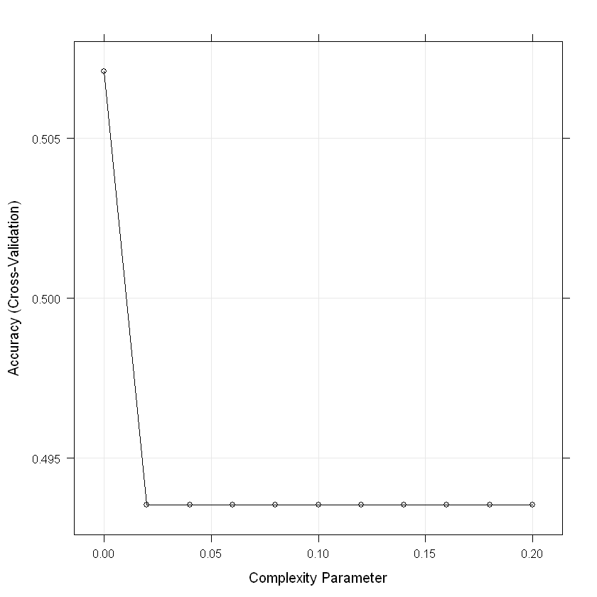

```r
numFolds=trainControl(method="cv",number = 10)
cpGrid=expand.grid(.cp=(0:10)*0.02)
#minbucket_grid=expand.grid(.cp=(5:10))
for(i in 100:105){
    tr=train(y~.,
          data=train_dt,
          method="rpart",
          trControl=numFolds,
          tuneGrid= cpGrid,
            # minbucket=minbucket_grid
           control= rpart.control(minbucket = i)
            )
    trellis.par.set(caretTheme())
    print(plot(tr))
    print(tr)
}
```

```
CART

4656 samples
 164 predictor
   5 classes: '1', '2', '3', '4', '5'

No pre-processing
Resampling: Cross-Validated (10 fold)
Summary of sample sizes: 4190, 4192, 4190, 4190, 4191, 4191, ...
Resampling results across tuning parameters:

  cp    Accuracy   Kappa
  0.00  0.4641210  0.2867510
  0.01  0.4935627  0.2805461
  0.02  0.4935627  0.2805461
  0.03  0.4935627  0.2805461
  0.04  0.4935627  0.2805461
  0.05  0.4935627  0.2805461
  0.06  0.4935627  0.2805461
  0.07  0.4935627  0.2805461
  0.08  0.4935627  0.2805461
  0.09  0.4935627  0.2805461
  0.10  0.4935627  0.2805461

Accuracy was used to select the optimal model using the largest value.
The final value used for the model was cp = 0.1.
```

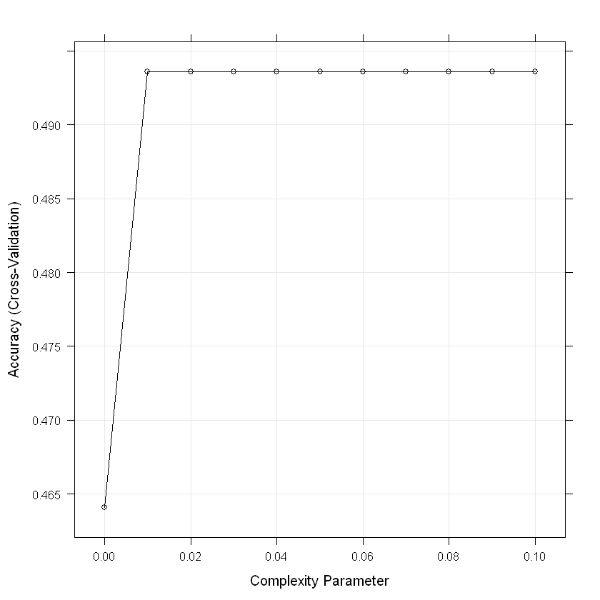

```r
numFolds=trainControl(method="cv",number = 10)
cpGrid=expand.grid(.cp=(0:10)*0.01)
tr_last=train(y~.,
      data=train_dt,
      method="rpart",
      trControl=numFolds,
      tuneGrid= cpGrid,
        # minbucket=minbucket_grid
       control= rpart.control(minsplit = 8)
        )
trellis.par.set(caretTheme())
print(plot(tr_last))
print(tr_last)
```

**attendance_0**

519.073230534664

**Q17_1**

31.4487364428168

**Q25_1**

24.0092504025806

**Q14_1**

21.3039827515856

**Q15_1**

20.6276658388369

**Q3_1**

20.2895073824625

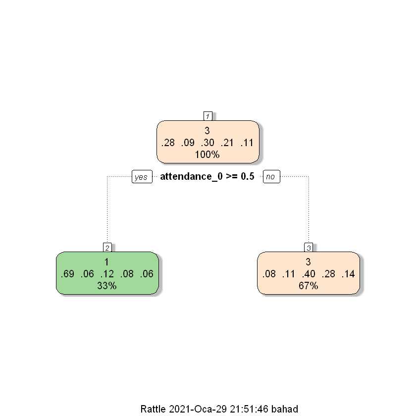

```r
reg_tree_std=tr$finalModel
fancyRpartPlot(reg_tree_std)
reg_tree_std$variable.importance
```

```r
predicted_std=predict(reg_tree_std,newdata=test_dt,type="class")
```

```r
table(predicted_std)
```

```
predicted_std
  1   2   3   4   5
367   0 797   0   0
```

### Performanca Measure

```r
confusionMatrix(data = as.factor(predicted_std), reference = as.factor(test$y), mode = "prec_recall")
```

```
Confusion Matrix and Statistics

          Reference
Prediction   1   2   3   4   5
         1 257  14  40  24  32
         2   0   0   0   0   0
         3  67  96 315 221  98
         4   0   0   0   0   0
         5   0   0   0   0   0

Overall Statistics

               Accuracy : 0.4914
                 95% CI : (0.4623, 0.5205)
    No Information Rate : 0.305
    P-Value [Acc > NIR] : < 2.2e-16

                  Kappa : 0.277

 Mcnemar's Test P-Value : NA

Statistics by Class:

                     Class: 1 Class: 2 Class: 3 Class: 4 Class: 5
Precision              0.7003       NA   0.3952       NA       NA
Recall                 0.7932   0.0000   0.8873   0.0000   0.0000
F1                     0.7438       NA   0.5469       NA       NA
Prevalence             0.2784   0.0945   0.3050   0.2105   0.1117
Detection Rate         0.2208   0.0000   0.2706   0.0000   0.0000
Detection Prevalence   0.3153   0.0000   0.6847   0.0000   0.0000
Balanced Accuracy      0.8311   0.5000   0.6458   0.5000   0.5000
```

```r
perf_dt("First Data Set for Decision Tree", as.numeric(predicted_std), as.numeric(test$y))
```

| name | n | mean | sd | FBias | MAPE | RMSE | MAD | WMAPE |
| --- | --- | --- | --- | --- | --- | --- | --- | --- |
| First Data Set for Decision Tree | 1164 | 2.369416 | 0.9296636 | -0.1744017 | 0.437858 | 0.03724006 | 0.8084192 | 0.3411893 |

## Random Forest(RF)

```r
library(ranger)
```

```r
fitControl=trainControl(method = "repeatedcv",
                           number = 10)
```

```r
rf_grid=expand.grid(mtry=c(4,8,10,15),
                   splitrule = c("extratrees"),
                   min.node.size= c(5))
rf_grid
```

| mtry | splitrule | min.node.size |
| --- | --- | --- |
| 4 | extratrees | 5 |
| 8 | extratrees | 5 |
| 10 | extratrees | 5 |
| 15 | extratrees | 5 |

```r
rf_fit=train(y ~ ., data = train,
                 method = "ranger",
                 trControl = fitControl, num.trees=500,
                 tuneGrid = rf_grid)
```

```
Random Forest

4656 samples
  32 predictor
   5 classes: '1', '2', '3', '4', '5'

No pre-processing
Resampling: Cross-Validated (10 fold, repeated 1 times)
Summary of sample sizes: 4190, 4191, 4190, 4190, 4190, 4192, ...
Resampling results across tuning parameters:

  mtry  Accuracy   Kappa
   4    0.4374783  0.2109921
   8    0.4819396  0.2853275
  10    0.4886044  0.2969695
  15    0.4920430  0.3057549

Tuning parameter 'splitrule' was held constant at a value of extratrees

Tuning parameter 'min.node.size' was held constant at a value of 5
Accuracy was used to select the optimal model using the largest value.
The final values used for the model were mtry = 15, splitrule = extratrees
 and min.node.size = 5.
```

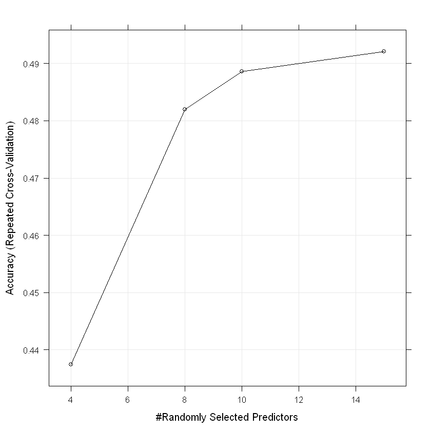

```r
rf_fit
plot(rf_fit)
```

```r
RandomForest_std=predict(rf_fit,newdata=test)
```

### Performanca Measure

```r
perf_dt("First Data Set for Random Forest", as.numeric(RandomForest_std), as.numeric(test$y))
```

| name | n | mean | sd | FBias | MAPE | RMSE | MAD | WMAPE |
| --- | --- | --- | --- | --- | --- | --- | --- | --- |
| First Data Set for Random Forest | 1164 | 2.66323 | 1.199737 | -0.04483871 | 0.3870275 | 0.03781045 | 0.8049828 | 0.3022581 |

```r
confusionMatrix(data = as.factor(RandomForest_std), reference = as.factor(test$y), mode = "prec_recall")
```

```
Confusion Matrix and Statistics

          Reference
Prediction   1   2   3   4   5
         1 242  11  37  20  23
         2   0  14   7   6   3
         3  58  70 246 137  56
         4  15  13  47  65  24
         5   9   2  18  17  24

Overall Statistics

               Accuracy : 0.5077
                 95% CI : (0.4786, 0.5368)
    No Information Rate : 0.305
    P-Value [Acc > NIR] : < 2.2e-16

                  Kappa : 0.3284

 Mcnemar's Test P-Value : < 2.2e-16

Statistics by Class:

                     Class: 1 Class: 2 Class: 3 Class: 4 Class: 5
Precision              0.7267  0.46667   0.4339  0.39634  0.34286
Recall                 0.7469  0.12727   0.6930  0.26531  0.18462
F1                     0.7367  0.20000   0.5336  0.31785  0.24000
Prevalence             0.2784  0.09450   0.3050  0.21048  0.11168
Detection Rate         0.2079  0.01203   0.2113  0.05584  0.02062
Detection Prevalence   0.2861  0.02577   0.4871  0.14089  0.06014
Balanced Accuracy      0.8193  0.55605   0.6481  0.57879  0.57006
```

### Performanca Measure

```r
perf_dt("First Data Set for Random Forest", as.numeric(RandomForest_std), as.numeric(test$y))
```

| name | n | mean | sd | FBias | MAPE | RMSE | MAD | WMAPE |
| --- | --- | --- | --- | --- | --- | --- | --- | --- |
| First Data Set for Random Forest | 1164 | 2.66323 | 1.199737 | -0.04483871 | 0.3870275 | 0.03781045 | 0.8049828 | 0.3022581 |

## Stochastic Gradient Boosting(SGB)

```r
set.seed(35)
```

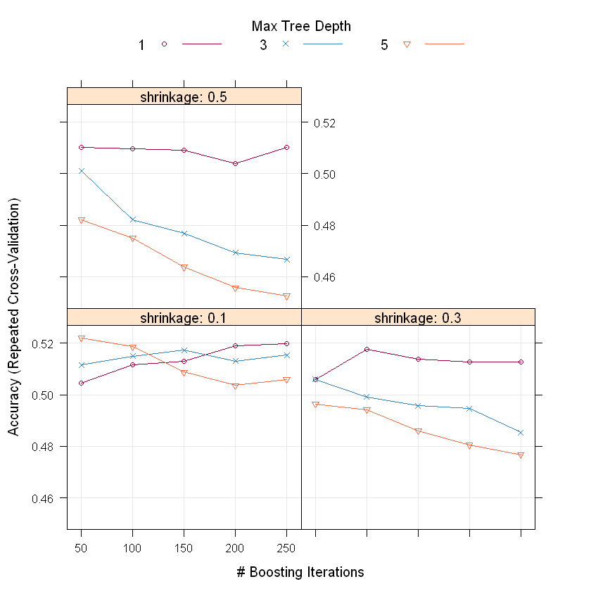

```r
gbmGrid=expand.grid(interaction.depth = c(1, 3, 5),
                        n.trees = (1:5)*50,
                        shrinkage = c(0.1, 0.3, 0.5),
                        n.minobsinnode = 20)


gbm_fit=train(y ~ ., data = train,
                 method = "gbm",
                 trControl = fitControl,
                 tuneGrid = gbmGrid,
                 verbose=F) #verbose is an argument from gbm, prints to screen

plot(gbm_fit)
```

```r
predicted_sgb=predict(gbm_fit,test)
```

### Performanca Measure

```r
confusionMatrix(data = as.factor(predicted_sgb), reference = as.factor(test$y), mode = "prec_recall")
```

```
Confusion Matrix and Statistics

          Reference
Prediction   1   2   3   4   5
         1 254  11  33  21  30
         2   1  13  12   4   2
         3  47  70 243 141  48
         4  15  12  45  65  26
         5   7   4  22  14  24

Overall Statistics

               Accuracy : 0.5146
                 95% CI : (0.4855, 0.5437)
    No Information Rate : 0.305
    P-Value [Acc > NIR] : < 2.2e-16

                  Kappa : 0.3385

 Mcnemar's Test P-Value : < 2.2e-16

Statistics by Class:

                     Class: 1 Class: 2 Class: 3 Class: 4 Class: 5
Precision              0.7278  0.40625   0.4426  0.39877  0.33803
Recall                 0.7840  0.11818   0.6845  0.26531  0.18462
F1                     0.7548  0.18310   0.5376  0.31863  0.23881
Prevalence             0.2784  0.09450   0.3050  0.21048  0.11168
Detection Rate         0.2182  0.01117   0.2088  0.05584  0.02062
Detection Prevalence   0.2998  0.02749   0.4716  0.14003  0.06100
Balanced Accuracy      0.8354  0.55008   0.6531  0.57933  0.56958
```

```r
perf_dt("First Data Set for Random Forest", as.numeric(predicted_sgb), as.numeric(test$y))
```

| name | n | mean | sd | FBias | MAPE | RMSE | MAD | WMAPE |
| --- | --- | --- | --- | --- | --- | --- | --- | --- |
| First Data Set for Random Forest | 1164 | 2.63488 | 1.216052 | -0.05608086 | 0.3967068 | 0.03797601 | 0.7955326 | 0.3019237 |

# General Result for 4 Method for Student Evaluation

### Linear Regression with Penalty

```r
lrp=confusionMatrix(data = as.factor(prediction_pra_mae_min), reference = as.factor(test$y), mode = "prec_recall")
lrp
```

```
Confusion Matrix and Statistics

          Reference
Prediction   1   2   3   4   5
         1 249  28  61  49  37
         2   0   1   0   1   0
         3  57  70 255 155  60
         4   9   8  23  29  14
         5   9   3  16  11  19

Overall Statistics

               Accuracy : 0.4751
                 95% CI : (0.4461, 0.5042)
    No Information Rate : 0.305
    P-Value [Acc > NIR] : < 2.2e-16

                  Kappa : 0.2724

 Mcnemar's Test P-Value : < 2.2e-16

Statistics by Class:

                     Class: 1  Class: 2 Class: 3 Class: 4 Class: 5
Precision              0.5873 0.5000000   0.4271  0.34940  0.32759
Recall                 0.7685 0.0090909   0.7183  0.11837  0.14615
F1                     0.6658 0.0178571   0.5357  0.17683  0.20213
Prevalence             0.2784 0.0945017   0.3050  0.21048  0.11168
Detection Rate         0.2139 0.0008591   0.2191  0.02491  0.01632
Detection Prevalence   0.3643 0.0017182   0.5129  0.07131  0.04983
Balanced Accuracy      0.7801 0.5040711   0.6478  0.52980  0.55422
```

### Decision Tree

```r
dtr=confusionMatrix(data = as.factor(predicted_std), reference = as.factor(test$y), mode = "prec_recall")
dtr
```

```
Confusion Matrix and Statistics

          Reference
Prediction   1   2   3   4   5
         1 257  14  40  24  32
         2   0   0   0   0   0
         3  67  96 315 221  98
         4   0   0   0   0   0
         5   0   0   0   0   0

Overall Statistics

               Accuracy : 0.4914
                 95% CI : (0.4623, 0.5205)
    No Information Rate : 0.305
    P-Value [Acc > NIR] : < 2.2e-16

                  Kappa : 0.277

 Mcnemar's Test P-Value : NA

Statistics by Class:

                     Class: 1 Class: 2 Class: 3 Class: 4 Class: 5
Precision              0.7003       NA   0.3952       NA       NA
Recall                 0.7932   0.0000   0.8873   0.0000   0.0000
F1                     0.7438       NA   0.5469       NA       NA
Prevalence             0.2784   0.0945   0.3050   0.2105   0.1117
Detection Rate         0.2208   0.0000   0.2706   0.0000   0.0000
Detection Prevalence   0.3153   0.0000   0.6847   0.0000   0.0000
Balanced Accuracy      0.8311   0.5000   0.6458   0.5000   0.5000
```

### Random Forest

```r
rfr=confusionMatrix(data = as.factor(RandomForest_std), reference = as.factor(test$y), mode = "prec_recall")
rfr
```

```
Confusion Matrix and Statistics

          Reference
Prediction   1   2   3   4   5
         1 242  11  37  20  23
         2   0  14   7   6   3
         3  58  70 246 137  56
         4  15  13  47  65  24
         5   9   2  18  17  24

Overall Statistics

               Accuracy : 0.5077
                 95% CI : (0.4786, 0.5368)
    No Information Rate : 0.305
    P-Value [Acc > NIR] : < 2.2e-16

                  Kappa : 0.3284

 Mcnemar's Test P-Value : < 2.2e-16

Statistics by Class:

                     Class: 1 Class: 2 Class: 3 Class: 4 Class: 5
Precision              0.7267  0.46667   0.4339  0.39634  0.34286
Recall                 0.7469  0.12727   0.6930  0.26531  0.18462
F1                     0.7367  0.20000   0.5336  0.31785  0.24000
Prevalence             0.2784  0.09450   0.3050  0.21048  0.11168
Detection Rate         0.2079  0.01203   0.2113  0.05584  0.02062
Detection Prevalence   0.2861  0.02577   0.4871  0.14089  0.06014
Balanced Accuracy      0.8193  0.55605   0.6481  0.57879  0.57006
```

### Stochastic Gradient Boosting

```r
sgbr=confusionMatrix(data = as.factor(predicted_sgb), reference = as.factor(test$y), mode = "prec_recall")
sgbr
```

```
Confusion Matrix and Statistics

          Reference
Prediction   1   2   3   4   5
         1 254  11  33  21  30
         2   1  13  12   4   2
         3  47  70 243 141  48
         4  15  12  45  65  26
         5   7   4  22  14  24

Overall Statistics

               Accuracy : 0.5146
                 95% CI : (0.4855, 0.5437)
    No Information Rate : 0.305
    P-Value [Acc > NIR] : < 2.2e-16

                  Kappa : 0.3385

 Mcnemar's Test P-Value : < 2.2e-16

Statistics by Class:

                     Class: 1 Class: 2 Class: 3 Class: 4 Class: 5
Precision              0.7278  0.40625   0.4426  0.39877  0.33803
Recall                 0.7840  0.11818   0.6845  0.26531  0.18462
F1                     0.7548  0.18310   0.5376  0.31863  0.23881
Prevalence             0.2784  0.09450   0.3050  0.21048  0.11168
Detection Rate         0.2182  0.01117   0.2088  0.05584  0.02062
Detection Prevalence   0.2998  0.02749   0.4716  0.14003  0.06100
Balanced Accuracy      0.8354  0.55008   0.6531  0.57933  0.56958
```

By looking the Accuracy, it can be said that best performance are optained in the Random Forest and Stochastic Gradient Boosting. Indeed, these 2 model's performance is too similar, which can be understood by looking the Precision, Recall, and F1 score of the models. The biggest difference occurs in the precision and recall values of the model. So, main objective can determine which model must be used. Moreover, performance of the other two model is also similar. Indeed decision tree's approach is more proper for classification problems. The reason behind the similarity can be explained by complexity of the models. Namely, Decision Tree's complexity is less than constructed Linear Regression with lasso, but it still has similar performance compared to the other.

# Conclusion of Models

## Linear Regression with Penalty

```r
lm_model
```

```
glmnet

4656 samples
  32 predictor
   5 classes: '1', '2', '3', '4', '5'

No pre-processing
Resampling: Cross-Validated (10 fold, repeated 1 times)
Summary of sample sizes: 4190, 4190, 4190, 4191, 4190, 4192, ...
Resampling results across tuning parameters:

  lambda       Accuracy   Kappa
  0.002179314  0.5199788  0.3445326
  0.007304193  0.5158988  0.3296490
  0.098829223  0.3047682  0.0000000

Tuning parameter 'alpha' was held constant at a value of 1
Accuracy was used to select the optimal model using the largest value.
The final values used for the model were alpha = 1 and lambda = 0.002179314.
```

### Best Model for Penalized Regression Approach

```r
print(lrp$overall[1])
```

```
 Accuracy
0.4750859
```

## Decision Tree

```r
tr_last
```

```
CART

4656 samples
 164 predictor
   5 classes: '1', '2', '3', '4', '5'

No pre-processing
Resampling: Cross-Validated (10 fold)
Summary of sample sizes: 4190, 4192, 4190, 4190, 4191, 4191, ...
Resampling results across tuning parameters:

  cp    Accuracy   Kappa
  0.00  0.4641210  0.2867510
  0.01  0.4935627  0.2805461
  0.02  0.4935627  0.2805461
  0.03  0.4935627  0.2805461
  0.04  0.4935627  0.2805461
  0.05  0.4935627  0.2805461
  0.06  0.4935627  0.2805461
  0.07  0.4935627  0.2805461
  0.08  0.4935627  0.2805461
  0.09  0.4935627  0.2805461
  0.10  0.4935627  0.2805461

Accuracy was used to select the optimal model using the largest value.
The final value used for the model was cp = 0.1.
```

### Best Model for Decision Tree

```r
print(dtr$overall[1])
```

```
 Accuracy
0.4914089
```

## Random Forest

```r
rf_fit
```

```
Random Forest

4656 samples
  32 predictor
   5 classes: '1', '2', '3', '4', '5'

No pre-processing
Resampling: Cross-Validated (10 fold, repeated 1 times)
Summary of sample sizes: 4190, 4191, 4190, 4190, 4190, 4192, ...
Resampling results across tuning parameters:

  mtry  Accuracy   Kappa
   4    0.4374783  0.2109921
   8    0.4819396  0.2853275
  10    0.4886044  0.2969695
  15    0.4920430  0.3057549

Tuning parameter 'splitrule' was held constant at a value of extratrees

Tuning parameter 'min.node.size' was held constant at a value of 5
Accuracy was used to select the optimal model using the largest value.
The final values used for the model were mtry = 15, splitrule = extratrees
 and min.node.size = 5.
```

### Best Model for Random Forest

```r
print(rfr$overall[1])
```

```
Accuracy
0.507732
```

## Stochastic Gradient Boosting

```r
gbm_fit
```

```
Stochastic Gradient Boosting

4656 samples
  32 predictor
   5 classes: '1', '2', '3', '4', '5'

No pre-processing
Resampling: Cross-Validated (10 fold, repeated 1 times)
Summary of sample sizes: 4191, 4191, 4191, 4190, 4190, 4189, ...
Resampling results across tuning parameters:

  shrinkage  interaction.depth  n.trees  Accuracy   Kappa
  0.1        1                   50      0.5045147  0.3078019
  0.1        1                  100      0.5116004  0.3253585
  0.1        1                  150      0.5128862  0.3312142
  0.1        1                  200      0.5189012  0.3425569
  0.1        1                  250      0.5199714  0.3450251
  0.1        3                   50      0.5116027  0.3307548
  0.1        3                  100      0.5150413  0.3412033
  0.1        3                  150      0.5173949  0.3463261
  0.1        3                  200      0.5131017  0.3420885
  0.1        3                  250      0.5154663  0.3455269
  0.1        5                   50      0.5221169  0.3483885
  0.1        5                  100      0.5186834  0.3484588
  0.1        5                  150      0.5088006  0.3374475
  0.1        5                  200      0.5036458  0.3321000
  0.1        5                  250      0.5060132  0.3359096
  0.3        1                   50      0.5060192  0.3232565
  0.3        1                  100      0.5176113  0.3432444
  0.3        1                  150      0.5139702  0.3397873
  0.3        1                  200      0.5126789  0.3391042
  0.3        1                  250      0.5126766  0.3395951
  0.3        3                   50      0.5060077  0.3321892
  0.3        3                  100      0.4991361  0.3268248
  0.3        3                  150      0.4957054  0.3237940
  0.3        3                  200      0.4946324  0.3238476
  0.3        3                  250      0.4853925  0.3122594
  0.3        5                   50      0.4963469  0.3233189
  0.3        5                  100      0.4942009  0.3236316
  0.3        5                  150      0.4860349  0.3132129
  0.3        5                  200      0.4804522  0.3073159
  0.3        5                  250      0.4768019  0.3029899
  0.5        1                   50      0.5103133  0.3317787
  0.5        1                  100      0.5096709  0.3342149
  0.5        1                  150      0.5092362  0.3356185
  0.5        1                  200      0.5038696  0.3274632
  0.5        1                  250      0.5103120  0.3385400
  0.5        3                   50      0.5010790  0.3317603
  0.5        3                  100      0.4821731  0.3081454
  0.5        3                  150      0.4768032  0.3023704
  0.5        3                  200      0.4692708  0.2936197
  0.5        3                  250      0.4666976  0.2907881
  0.5        5                   50      0.4821699  0.3085435
  0.5        5                  100      0.4750957  0.3022930
  0.5        5                  150      0.4637080  0.2876027
  0.5        5                  200      0.4557584  0.2760911
  0.5        5                  250      0.4525368  0.2733735

Tuning parameter 'n.minobsinnode' was held constant at a value of 20
Accuracy was used to select the optimal model using the largest value.
The final values used for the model were n.trees = 50, interaction.depth =
 5, shrinkage = 0.1 and n.minobsinnode = 20.
```

### Best Model for Stochastic Gradient Boosting

```r
print(sgbr$overall[1])
```

```
 Accuracy
0.5146048
```

# Comparision of Results in Training and Test Dataset

```r
train=list("Linear Regression with Lasso Results"=lm_model$results$Accuracy[which.min(lm_model$results$Accuracy)],
            "Decision Tree Results"=    tr_last$results$Accuracy[which.min(tr_last$results$Accuracy)],
            "Random Forest Results"=    rf_fit$results$Accuracy[which.min(rf_fit$results$Accuracy)],
            "Result Stochastic Gradient Boosting Results"=    gbm_fit$results$Accuracy[which.min(gbm_fit$results$Accuracy)])
```

## Accuracy in The Train Dataset¶

```r
t(train)
```

[output not shown]

```r
test=list("Linear Regression with Lasso Results"=lrp$overall[1],
            "Decision Tree Results"=    dtr$overall[1],
            "Random Forest Results"=    rfr$overall[1],
            "Result Stochastic Gradient Boosting Results"=    sgbr$overall[1])
```

## Accuracy in The Test Dataset

```r
t(test)
```

| Linear Regression with Lasso Results | Decision Tree Results | Random Forest Results | Result Stochastic Gradient Boosting Results |
| --- | --- | --- | --- |
| 0.4750859 | 0.4914089 | 0.507732 | 0.5146048 |

Models got similar performance as achieved in the training dataset. Namely, it is hard to say that there is an over-fitting or under-fitting. Student Evaluation values can be described as nulti-classification problem, so having the worst performance measure both training and test data sets aren't a suprise for Linear Regression model. In addition to under/over-fitting, it can be said that error rates are consistent for both datasets, which can be observed looking the correlation between the results pf performance of the models in both dataset. Interestingly, all the models have more accuracy in the test dataset. However, accuracy can be bad performance measure for this type dataset(imbalance in the dataset) because by having a bias in the major part of the class, model still can get better accuracy at the end. The reason behind this fact occured from the formula of the Accuracy measurement. So, F1-Score or Recall can be more reasonable to compare the models.